# Red wine quality

Rajeev

06/12/2019

- Introduction
- Inspect and pre-process
  - Select variables
  - Inspect and transform 1: individual variables
  - Inspect and transform 2: Multivariable relationship Inspect and transform 2: Multivariable relationship
  - Target ~ predictor relationships
  - Modeling
  - Interpreting coefficients
- Summary

## Introduction

**Data:** My [dataset](https://www.kaggle.com/uciml/red-wine-quality-cortez-et-al-2009) contains features that can be used to determine the quality of a red wine. Each row represents one red wine type.

**Goals:**Goals are to predict and classify the red wine quality as 0 *bad* or 1 *good* and also to answer the question *Is this red wine good for health?*

## Inspect and pre-process

```r
# load libraries
library(tidyverse)
library(gridExtra)
library(psych)
library(caret)
library(factoextra)

# load data
red<- read.csv("D:/subjects/datamining new/red-wine-quality-cortez-et-al-2009/winequality-red.csv")
wine<- read.csv("D:/subjects/datamining new/red-wine-quality-cortez-et-al-2009/winequality-red.csv")

# Number of rows/columns
red %>% dim()
```

```
## [1] 1599   12
```

The Red wine quality dataset contains 1599 rows(each red wine) and 12 columns (features of a red wine).

```r
# summary of dataset
red %>% summary
```

```
##  fixed.acidity   volatile.acidity  citric.acid    residual.sugar
##  Min.   : 4.60   Min.   :0.1200   Min.   :0.000   Min.   : 0.900
##  1st Qu.: 7.10   1st Qu.:0.3900   1st Qu.:0.090   1st Qu.: 1.900
##  Median : 7.90   Median :0.5200   Median :0.260   Median : 2.200
##  Mean   : 8.32   Mean   :0.5278   Mean   :0.271   Mean   : 2.539
##  3rd Qu.: 9.20   3rd Qu.:0.6400   3rd Qu.:0.420   3rd Qu.: 2.600
##  Max.   :15.90   Max.   :1.5800   Max.   :1.000   Max.   :15.500
##    chlorides       free.sulfur.dioxide total.sulfur.dioxide
##  Min.   :0.01200   Min.   : 1.00       Min.   :  6.00
##  1st Qu.:0.07000   1st Qu.: 7.00       1st Qu.: 22.00
##  Median :0.07900   Median :14.00       Median : 38.00
##  Mean   :0.08747   Mean   :15.87       Mean   : 46.47
##  3rd Qu.:0.09000   3rd Qu.:21.00       3rd Qu.: 62.00
##  Max.   :0.61100   Max.   :72.00       Max.   :289.00
##     density             pH          sulphates         alcohol
##  Min.   :0.9901   Min.   :2.740   Min.   :0.3300   Min.   : 8.40
##  1st Qu.:0.9956   1st Qu.:3.210   1st Qu.:0.5500   1st Qu.: 9.50
##  Median :0.9968   Median :3.310   Median :0.6200   Median :10.20
##  Mean   :0.9967   Mean   :3.311   Mean   :0.6581   Mean   :10.42
##  3rd Qu.:0.9978   3rd Qu.:3.400   3rd Qu.:0.7300   3rd Qu.:11.10
##  Max.   :1.0037   Max.   :4.010   Max.   :2.0000   Max.   :14.90
##     quality
##  Min.   :3.000
##  1st Qu.:5.000
##  Median :6.000
##  Mean   :5.636
##  3rd Qu.:6.000
##  Max.   :8.000
```

This dataset is completely cleaned one with no missing values and all the variables are numerical and quality variable is to be converted from int to binary.

### Select variables

I have selected 11 variables i.e. 10 predictor variables and 1 target variable ‘quality’:

- `Fixed-acidity:`has acidic nature values in it.
- `Volatile-acidity:`has acetic acid composition values.
- `Critic acid:`this adds freshness to wine.
- `Residual sugar:` is amount of sugar in gram/liter values.
- `Chlorides:` this contains amount of salt.
- `Free sulfur dioxide` and `total sulfur dioxide` is the portion of so2 that is free in the wine plus the portion that is bound to other chemicals in the wine such as aldehydes, pigments or sugars.
- `Density:` this is ratio of water to alcohol.
- `Ph:` is scale that determines the acidic nature of wine and cannot be dropped.
- `Alcohol:` is important variable which helps in classifying the wine.
- `Quality:` is the predictor variable from values 0 to 10, this is numerical and may be converted to binary variable.

```r
# select desired columns
red <- red %>% select(-sulphates)

# structure of selected variables
red %>% str
```

```
## 'data.frame':    1599 obs. of  11 variables:
##  $ fixed.acidity       : num  7.4 7.8 7.8 11.2 7.4 7.4 7.9 7.3 7.8 7.5 ...
##  $ volatile.acidity    : num  0.7 0.88 0.76 0.28 0.7 0.66 0.6 0.65 0.58 0.5 ...
##  $ citric.acid         : num  0 0 0.04 0.56 0 0 0.06 0 0.02 0.36 ...
##  $ residual.sugar      : num  1.9 2.6 2.3 1.9 1.9 1.8 1.6 1.2 2 6.1 ...
##  $ chlorides           : num  0.076 0.098 0.092 0.075 0.076 0.075 0.069 0.065 0.073 0.071 ...
##  $ free.sulfur.dioxide : num  11 25 15 17 11 13 15 15 9 17 ...
##  $ total.sulfur.dioxide: num  34 67 54 60 34 40 59 21 18 102 ...
##  $ density             : num  0.998 0.997 0.997 0.998 0.998 ...
##  $ pH                  : num  3.51 3.2 3.26 3.16 3.51 3.51 3.3 3.39 3.36 3.35 ...
##  $ alcohol             : num  9.4 9.8 9.8 9.8 9.4 9.4 9.4 10 9.5 10.5 ...
##  $ quality             : int  5 5 5 6 5 5 5 7 7 5 ...
```

The new data contains 11 columns and dropped `sulphates` variable because it has least correlation with target variable when compared to free sulfur dioxide and total sulfur dioxide.

## Inspect and transform 1: individual variables

The quality variable is converted into binary form like the quality value is greater than or equal to 6 it is considered as good or else bad.

```r
red$quality_binary<- ifelse(red$quality >= 6,1,0)
red<- red %>% select( -quality)

# table for transformed quality variable
red$quality_binary %>% table
```

```
## .
##   0   1
## 744 855
```

```r
red %>% head
```

```
##   fixed.acidity volatile.acidity citric.acid residual.sugar chlorides
## 1           7.4             0.70        0.00            1.9     0.076
## 2           7.8             0.88        0.00            2.6     0.098
## 3           7.8             0.76        0.04            2.3     0.092
## 4          11.2             0.28        0.56            1.9     0.075
## 5           7.4             0.70        0.00            1.9     0.076
## 6           7.4             0.66        0.00            1.8     0.075
##   free.sulfur.dioxide total.sulfur.dioxide density   pH alcohol
## 1                  11                   34  0.9978 3.51     9.4
## 2                  25                   67  0.9968 3.20     9.8
## 3                  15                   54  0.9970 3.26     9.8
## 4                  17                   60  0.9980 3.16     9.8
## 5                  11                   34  0.9978 3.51     9.4
## 6                  13                   40  0.9978 3.51     9.4
##   quality_binary
## 1              0
## 2              0
## 3              0
## 4              1
## 5              0
## 6              0
```

Rest of the 10 variables are continuous numerical variable so I need to plot histograms for them. Below are the comparison histograms of 8 variables i.e. before and after log transformation and two are already normally distributed.

#### Before Transformation

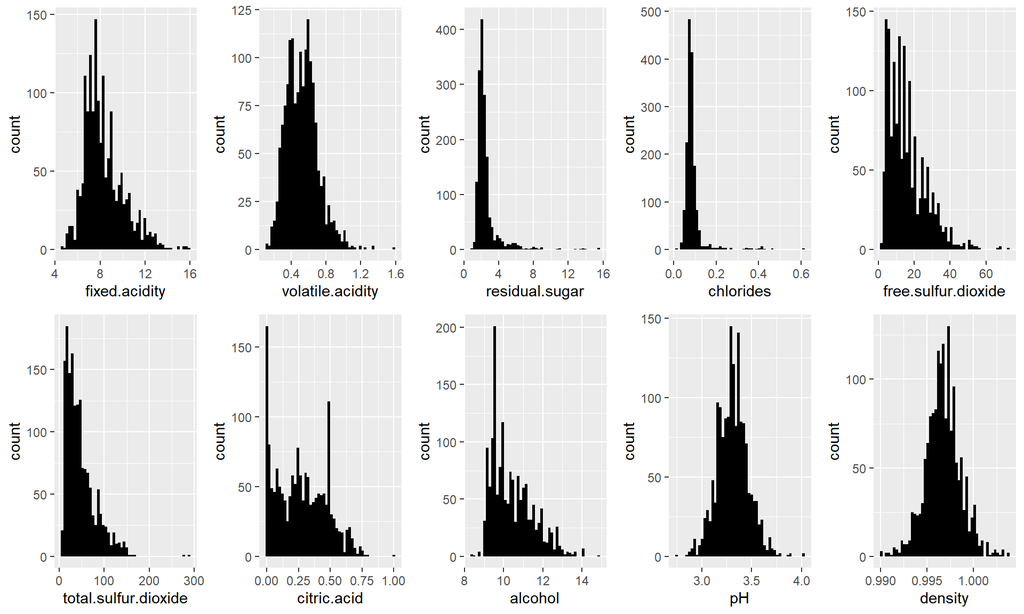

```r
g1<- red %>% ggplot(aes(x =fixed.acidity ))+ geom_histogram(bins=50, fill= 'black')
g2<- red %>% ggplot(aes(x =volatile.acidity ))+ geom_histogram(bins=50, fill= 'black')
g3<- red %>% ggplot(aes(x =residual.sugar ))+ geom_histogram(bins=50, fill= 'black')
g4<- red %>% ggplot(aes(x =chlorides ))+ geom_histogram(bins=50, fill= 'black')
g5<- red %>% ggplot(aes(x =free.sulfur.dioxide ))+ geom_histogram(bins=50, fill= 'black')
g6<- red %>% ggplot(aes(x =total.sulfur.dioxide ))+ geom_histogram(bins=50, fill= 'black')
g7<- red %>% ggplot(aes(x = citric.acid))+ geom_histogram(bins=50, fill= 'black')
g8<- red %>% ggplot(aes(x = alcohol))+ geom_histogram(bins=50, fill= 'black')
g9<- red %>% ggplot(aes(x = pH ))+ geom_histogram(bins=50, fill= 'black')
g10<- red %>% ggplot(aes(x =density ))+ geom_histogram(bins=50, fill= 'black')
grid.arrange(g1, g2, g3, g4, g5, g6, g7, g8,g9,g10, nrow=2)
```

#### After transformation

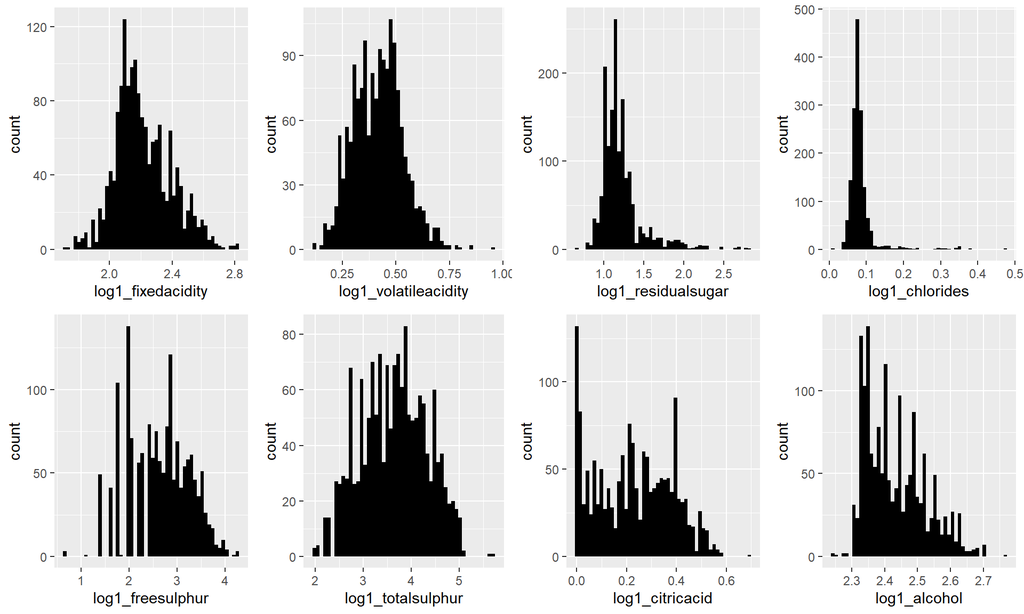

```r
red <- red %>%
  mutate(log1_fixedacidity= log1p(fixed.acidity)) %>%
  select(-fixed.acidity)
log_g1<- red %>% ggplot(aes(x =log1_fixedacidity))+ geom_histogram(bins=50, fill= 'black')

red <- red %>%
  mutate(log1_volatileacidity= log1p(volatile.acidity)) %>%
  select(-volatile.acidity)
log_g2<- red %>% ggplot(aes(x =log1_volatileacidity ))+ geom_histogram(bins=50, fill= 'black')

red <- red %>%
  mutate(log1_residualsugar= log1p(residual.sugar)) %>%
  select(-residual.sugar)
log_g3<- red %>% ggplot(aes(x =log1_residualsugar ))+ geom_histogram(bins=50, fill= 'black')

red <- red %>%
  mutate(log1_chlorides= log1p(chlorides)) %>%
  select(-chlorides)
log_g4<- red %>% ggplot(aes(x =log1_chlorides ))+ geom_histogram(bins=50, fill= 'black')

red <- red %>%
  mutate(log1_freesulphur= log1p(free.sulfur.dioxide)) %>%
  select(-free.sulfur.dioxide)
log_g5<- red %>% ggplot(aes(x =log1_freesulphur ))+ geom_histogram(bins=50, fill= 'black')

red <- red %>%
  mutate(log1_totalsulphur= log1p(total.sulfur.dioxide)) %>%
  select(-total.sulfur.dioxide)
log_g6<- red %>% ggplot(aes(x =log1_totalsulphur ))+ geom_histogram(bins=50, fill= 'black')

red <- red %>%
  mutate(log1_citricacid= log1p(citric.acid)) %>%
  select(-citric.acid)
log_g7<- red %>% ggplot(aes(x =log1_citricacid ))+ geom_histogram(bins=50, fill= 'black')

red <- red %>%
  mutate(log1_alcohol= log1p(alcohol)) %>%
  select(-alcohol)
log_g8<- red %>% ggplot(aes(x =log1_alcohol ))+ geom_histogram(bins=50, fill= 'black')

grid.arrange(log_g1,log_g2,log_g3,log_g4,log_g5,log_g6,log_g7,log_g8, nrow=2)
```